# CC2_ECOG2

```bash
sudo apt-get update -y
sudo apt-get install -y libglpk-dev
sudo apt-get install -y liblzma-dev libbz2-dev
```

[output not shown]

```r
if (!requireNamespace("BiocManager", quietly = TRUE))
    install.packages("BiocManager")
BiocManager::install("BiocStyle")
BiocManager::install("Rhtslib")
```

```r
library("knitr")
library("BiocStyle")
.cran_packages <- c("ggplot2", "gridExtra", "devtools")
install.packages(.cran_packages)
.bioc_packages <- c("dada2", "phyloseq", "DECIPHER", "phangorn")
BiocManager::install(.bioc_packages)
# Load packages into session, and print package version
sapply(c(.cran_packages, .bioc_packages), require, character.only = TRUE)
```

```
##   ggplot2 gridExtra  devtools     dada2  phyloseq  DECIPHER  phangorn
##      TRUE      TRUE      TRUE      TRUE      TRUE      TRUE      TRUE
```

```r
.cran_packages <- c( "shiny","miniUI", "caret", "pls", "e1071", "ggplot2", "randomForest", "dplyr", "ggrepel", "nlme", "devtools",
                  "reshape2", "PMA", "structSSI", "ade4",
                  "ggnetwork", "intergraph", "scales")
.github_packages <- c("jfukuyama/phyloseqGraphTest")
.bioc_packages <- c("genefilter", "impute")
```

```r
.inst <- .cran_packages %in% installed.packages()
if (any(!.inst)){
  install.packages(.cran_packages[!.inst],repos = "http://cran.rstudio.com/")
}
.inst <- .github_packages %in% installed.packages()
if (any(!.inst)){
  devtools::install_github(.github_packages[!.inst])
}
```

```
## Skipping install of 'phyloseqGraphTest' from a github remote, the SHA1 (3fb6c274) has not changed since last install.
##   Use `force = TRUE` to force installation
```

```r
.inst <- .bioc_packages %in% installed.packages()
if(any(!.inst)){BiocManager::install(.bioc_packages[!.inst])
}
```

Pour la taxonomie

```r
.cran_packages <- c( "shiny","miniUI", "caret", "pls", "e1071", "ggplot2", "randomForest", "dplyr", "ggrepel", "nlme", "devtools",
                  "reshape2", "PMA", "structSSI", "ade4",
                  "ggnetwork", "intergraph", "scales")
.github_packages <- c("jfukuyama/phyloseqGraphTest")
.bioc_packages <- c("genefilter", "impute")
# Install CRAN packages (if not already installed)
.inst <- .cran_packages %in% installed.packages()
if (any(!.inst)){
  install.packages(.cran_packages[!.inst],repos = "http://cran.rstudio.com/")
}
.inst <- .github_packages %in% installed.packages()
if (any(!.inst)){
  devtools::install_github(.github_packages[!.inst])
}
```

```
## Skipping install of 'phyloseqGraphTest' from a github remote, the SHA1 (3fb6c274) has not changed since last install.
##   Use `force = TRUE` to force installation
```

```r
.inst <- .bioc_packages %in% installed.packages()
if(any(!.inst)){
  source("http://bioconductor.org/biocLite.R")
  biocLite(.bioc_packages[!.inst])
}
```

```r
set.seed(100)
coraux <- "/home/rstudio/mydatalocal/CC2-EcoG2/ERR"
list.files(coraux)
```

```
##  [1] "ERR5862095_1.fastq.gz" "ERR5862095_2.fastq.gz" "ERR5862096_1.fastq.gz"
##  [4] "ERR5862096_2.fastq.gz" "ERR5862097_1.fastq.gz" "ERR5862097_2.fastq.gz"
##  [7] "ERR5862098_1.fastq.gz" "ERR5862098_2.fastq.gz" "ERR5862099_1.fastq.gz"
## [10] "ERR5862099_2.fastq.gz" "ERR5862100_1.fastq.gz" "ERR5862100_2.fastq.gz"
## [13] "ERR5862101_1.fastq.gz" "ERR5862101_2.fastq.gz" "ERR5862102_1.fastq.gz"
## [16] "ERR5862102_2.fastq.gz" "ERR5862103_1.fastq.gz" "ERR5862103_2.fastq.gz"
## [19] "ERR5862104_1.fastq.gz" "ERR5862104_2.fastq.gz" "ERR5862105_1.fastq.gz"
## [22] "ERR5862105_2.fastq.gz" "ERR5862106_1.fastq.gz" "ERR5862106_2.fastq.gz"
## [25] "ERR5862107_1.fastq.gz" "ERR5862107_2.fastq.gz" "ERR5862108_1.fastq.gz"
## [28] "ERR5862108_2.fastq.gz" "ERR5862109_1.fastq.gz" "ERR5862109_2.fastq.gz"
## [31] "ERR5862110_1.fastq.gz" "ERR5862110_2.fastq.gz" "ERR5862111_1.fastq.gz"
## [34] "ERR5862111_2.fastq.gz" "ERR5862112_1.fastq.gz" "ERR5862112_2.fastq.gz"
## [37] "ERR5862113_1.fastq.gz" "ERR5862113_2.fastq.gz" "ERR5862114_1.fastq.gz"
## [40] "ERR5862114_2.fastq.gz" "ERR5862115_1.fastq.gz" "ERR5862115_2.fastq.gz"
## [43] "ERR5862116_1.fastq.gz" "ERR5862116_2.fastq.gz" "ERR5862117_1.fastq.gz"
## [46] "ERR5862117_2.fastq.gz" "ERR5862118_1.fastq.gz" "ERR5862118_2.fastq.gz"
## [49] "filtered"
```

LECTURE DES FICHIERS (filtrer et rogner)

```r
#On tri pour que les reads "fnRs" soit lu dans le même ordre que les forward "fnFs"
fnFs <- sort(list.files(coraux, pattern="_1.fastq.gz"))
fnRs <- sort(list.files(coraux, pattern="_2.fastq.gz"))
```

Ici on prend le 1er élément de Fnfs en tant que liste séparée par des “_” et strip prend le premier élément de cette liste. On transforme un nom de fichier en nom d’échantillon (ici première partie de la liste)

```r
sampleNames <- sapply(strsplit(fnFs, "_"), `[`, 1)

# Specify the full path to the fnFs and fnRs
fnFs <- file.path(coraux, fnFs)
fnRs <- file.path(coraux, fnRs)

#On affiche les 3 premiers éléments de la liste, où ils sont enregistrés.
fnFs[1:3]
```

```
## [1] "/home/rstudio/mydatalocal/CC2-EcoG2/ERR/ERR5862095_1.fastq.gz"
## [2] "/home/rstudio/mydatalocal/CC2-EcoG2/ERR/ERR5862096_1.fastq.gz"
## [3] "/home/rstudio/mydatalocal/CC2-EcoG2/ERR/ERR5862097_1.fastq.gz"
```

```r
fnRs[1:3]
```

```
## [1] "/home/rstudio/mydatalocal/CC2-EcoG2/ERR/ERR5862095_2.fastq.gz"
## [2] "/home/rstudio/mydatalocal/CC2-EcoG2/ERR/ERR5862096_2.fastq.gz"
## [3] "/home/rstudio/mydatalocal/CC2-EcoG2/ERR/ERR5862097_2.fastq.gz"
```

La ligne verte correspond à la moyenne des scores de qualités pour tous le fichier. La ligne rouge correspond à la proportion des reads qui vont au moins jusqu’à la position de cette ligne.

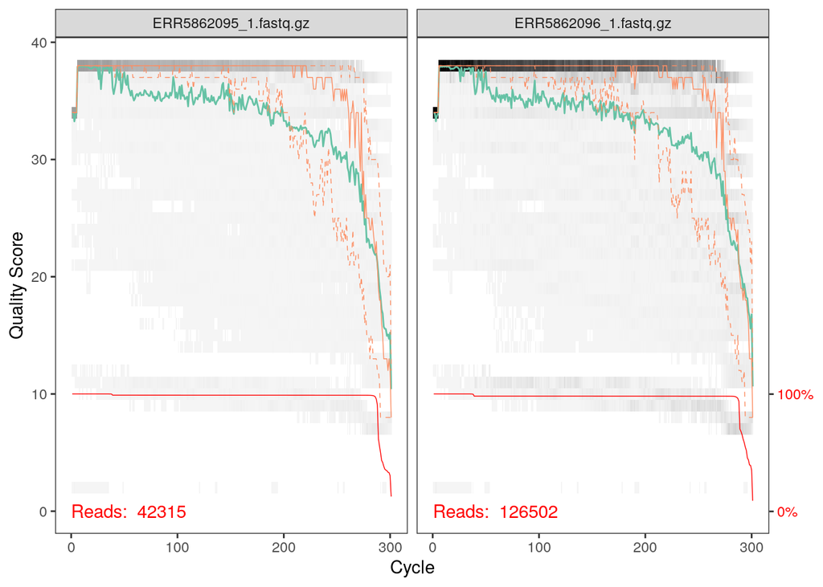

```r
#Dans les forwards, on remarque que les erreurs s'accumulent sur les fins de séquences, surtout à partir du nucléotides 260 (environ), puisqu'en effet le score de qualité passe de 30 à presque 10, engendrant ainsi une perte de la qualité de la séquence.
#Du premier nucléotides jusqu'au 200ème, le Qscore reste entre 38 et 33.

plotQualityProfile(fnFs[1:2])
```

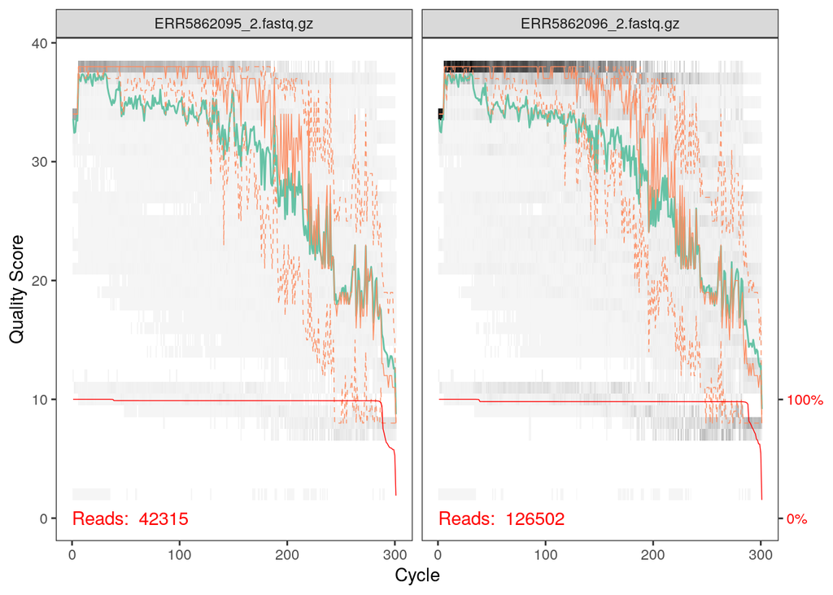

```r
#Ici on remarque que les séquences sont de qualité bien moindre que les précédentes, puisque le Qscore décroît beaucoup plus tôt, et varie davantages.
plotQualityProfile(fnRs[1:2])
```

Ces graphiques servent à définir les séquences de mauvaises qualités. A partir de la, on va filtrer les séquences en retirant les bases qui ont un score de qualité trop faible, et créer un nouveau fichier contenant ces nouvelles séquences.

On filtre les fichiers

```r
filt_path <- file.path(coraux, "filtered")
if(!file_test("-d", filt_path)) dir.create(filt_path)
filtFs <- file.path(filt_path, paste0(sampleNames, "_F_filt.fastq.gz"))
filtRs <- file.path(filt_path, paste0(sampleNames, "_R_filt.fastq.gz"))
```

Création d’une variable “out” qui reçoit le résultat de la fonction FilterAndTrim qui décrit ce qu’est chaque argument. Le 5e argument “trunclen c” permet de créer une variable à 2 valeurs: une pour les forwards l’autre pour les reverse.

```r
out <- filterAndTrim(fnFs, filtFs, fnRs, filtRs, truncLen=c(240,160),
              maxN=0, maxEE=c(2,2), truncQ=2, rm.phix=TRUE,
              compress=TRUE, multithread=TRUE)
head(out)
```

```
##                       reads.in reads.out
## ERR5862095_1.fastq.gz    42315     32124
## ERR5862096_1.fastq.gz   126502     92838
## ERR5862097_1.fastq.gz    65379     46643
## ERR5862098_1.fastq.gz   127555     94277
## ERR5862099_1.fastq.gz   146932    112817
## ERR5862100_1.fastq.gz   145654    109440
```

DEPLICATION: ici les séquences identiques ne sont gardés qu’une seule fois (les autres sont gardées en mémoire)

```r
derepFs <- derepFastq(filtFs, verbose=TRUE)
```

```
## Dereplicating sequence entries in Fastq file: /home/rstudio/mydatalocal/CC2-EcoG2/ERR/filtered/ERR5862095_F_filt.fastq.gz
```

```
## Encountered 15945 unique sequences from 32124 total sequences read.
```

```
## Dereplicating sequence entries in Fastq file: /home/rstudio/mydatalocal/CC2-EcoG2/ERR/filtered/ERR5862096_F_filt.fastq.gz
```

```
## Encountered 31325 unique sequences from 92838 total sequences read.
```

```
## Dereplicating sequence entries in Fastq file: /home/rstudio/mydatalocal/CC2-EcoG2/ERR/filtered/ERR5862097_F_filt.fastq.gz
```

```
## Encountered 16060 unique sequences from 46643 total sequences read.
```

```
## Dereplicating sequence entries in Fastq file: /home/rstudio/mydatalocal/CC2-EcoG2/ERR/filtered/ERR5862098_F_filt.fastq.gz
```

```
## Encountered 19732 unique sequences from 94277 total sequences read.
```

```
## Dereplicating sequence entries in Fastq file: /home/rstudio/mydatalocal/CC2-EcoG2/ERR/filtered/ERR5862099_F_filt.fastq.gz
```

```
## Encountered 26952 unique sequences from 112817 total sequences read.
```

```
## Dereplicating sequence entries in Fastq file: /home/rstudio/mydatalocal/CC2-EcoG2/ERR/filtered/ERR5862100_F_filt.fastq.gz
```

```
## Encountered 22492 unique sequences from 109440 total sequences read.
```

```
## Dereplicating sequence entries in Fastq file: /home/rstudio/mydatalocal/CC2-EcoG2/ERR/filtered/ERR5862101_F_filt.fastq.gz
```

```
## Encountered 24909 unique sequences from 163655 total sequences read.
```

```
## Dereplicating sequence entries in Fastq file: /home/rstudio/mydatalocal/CC2-EcoG2/ERR/filtered/ERR5862102_F_filt.fastq.gz
```

```
## Encountered 16844 unique sequences from 105908 total sequences read.
```

```
## Dereplicating sequence entries in Fastq file: /home/rstudio/mydatalocal/CC2-EcoG2/ERR/filtered/ERR5862103_F_filt.fastq.gz
```

```
## Encountered 29692 unique sequences from 194755 total sequences read.
```

```
## Dereplicating sequence entries in Fastq file: /home/rstudio/mydatalocal/CC2-EcoG2/ERR/filtered/ERR5862104_F_filt.fastq.gz
```

```
## Encountered 27166 unique sequences from 63926 total sequences read.
```

```
## Dereplicating sequence entries in Fastq file: /home/rstudio/mydatalocal/CC2-EcoG2/ERR/filtered/ERR5862105_F_filt.fastq.gz
```

```
## Encountered 14917 unique sequences from 76550 total sequences read.
```

```
## Dereplicating sequence entries in Fastq file: /home/rstudio/mydatalocal/CC2-EcoG2/ERR/filtered/ERR5862106_F_filt.fastq.gz
```

```
## Encountered 4682 unique sequences from 26037 total sequences read.
```

```
## Dereplicating sequence entries in Fastq file: /home/rstudio/mydatalocal/CC2-EcoG2/ERR/filtered/ERR5862107_F_filt.fastq.gz
```

```
## Encountered 33852 unique sequences from 150016 total sequences read.
```

```
## Dereplicating sequence entries in Fastq file: /home/rstudio/mydatalocal/CC2-EcoG2/ERR/filtered/ERR5862108_F_filt.fastq.gz
```

```
## Encountered 75083 unique sequences from 280864 total sequences read.
```

```
## Dereplicating sequence entries in Fastq file: /home/rstudio/mydatalocal/CC2-EcoG2/ERR/filtered/ERR5862109_F_filt.fastq.gz
```

```
## Encountered 56156 unique sequences from 185152 total sequences read.
```

```
## Dereplicating sequence entries in Fastq file: /home/rstudio/mydatalocal/CC2-EcoG2/ERR/filtered/ERR5862110_F_filt.fastq.gz
```

```
## Encountered 42991 unique sequences from 154076 total sequences read.
```

```
## Dereplicating sequence entries in Fastq file: /home/rstudio/mydatalocal/CC2-EcoG2/ERR/filtered/ERR5862111_F_filt.fastq.gz
```

```
## Encountered 36023 unique sequences from 111621 total sequences read.
```

```
## Dereplicating sequence entries in Fastq file: /home/rstudio/mydatalocal/CC2-EcoG2/ERR/filtered/ERR5862112_F_filt.fastq.gz
```

```
## Encountered 36085 unique sequences from 127863 total sequences read.
```

```
## Dereplicating sequence entries in Fastq file: /home/rstudio/mydatalocal/CC2-EcoG2/ERR/filtered/ERR5862113_F_filt.fastq.gz
```

```
## Encountered 67176 unique sequences from 309890 total sequences read.
```

```
## Dereplicating sequence entries in Fastq file: /home/rstudio/mydatalocal/CC2-EcoG2/ERR/filtered/ERR5862114_F_filt.fastq.gz
```

```
## Encountered 29753 unique sequences from 85811 total sequences read.
```

```
## Dereplicating sequence entries in Fastq file: /home/rstudio/mydatalocal/CC2-EcoG2/ERR/filtered/ERR5862115_F_filt.fastq.gz
```

```
## Encountered 46146 unique sequences from 200131 total sequences read.
```

```
## Dereplicating sequence entries in Fastq file: /home/rstudio/mydatalocal/CC2-EcoG2/ERR/filtered/ERR5862116_F_filt.fastq.gz
```

```
## Encountered 39647 unique sequences from 151300 total sequences read.
```

```
## Dereplicating sequence entries in Fastq file: /home/rstudio/mydatalocal/CC2-EcoG2/ERR/filtered/ERR5862117_F_filt.fastq.gz
```

```
## Encountered 53402 unique sequences from 158874 total sequences read.
```

```
## Dereplicating sequence entries in Fastq file: /home/rstudio/mydatalocal/CC2-EcoG2/ERR/filtered/ERR5862118_F_filt.fastq.gz
```

```
## Encountered 11271 unique sequences from 34173 total sequences read.
```

```r
derepRs <- derepFastq(filtRs, verbose=TRUE)
```

```
## Dereplicating sequence entries in Fastq file: /home/rstudio/mydatalocal/CC2-EcoG2/ERR/filtered/ERR5862095_R_filt.fastq.gz
```

```
## Encountered 12951 unique sequences from 32124 total sequences read.
```

```
## Dereplicating sequence entries in Fastq file: /home/rstudio/mydatalocal/CC2-EcoG2/ERR/filtered/ERR5862096_R_filt.fastq.gz
```

```
## Encountered 29574 unique sequences from 92838 total sequences read.
```

```
## Dereplicating sequence entries in Fastq file: /home/rstudio/mydatalocal/CC2-EcoG2/ERR/filtered/ERR5862097_R_filt.fastq.gz
```

```
## Encountered 15456 unique sequences from 46643 total sequences read.
```

```
## Dereplicating sequence entries in Fastq file: /home/rstudio/mydatalocal/CC2-EcoG2/ERR/filtered/ERR5862098_R_filt.fastq.gz
```

```
## Encountered 19813 unique sequences from 94277 total sequences read.
```

```
## Dereplicating sequence entries in Fastq file: /home/rstudio/mydatalocal/CC2-EcoG2/ERR/filtered/ERR5862099_R_filt.fastq.gz
```

```
## Encountered 26574 unique sequences from 112817 total sequences read.
```

```
## Dereplicating sequence entries in Fastq file: /home/rstudio/mydatalocal/CC2-EcoG2/ERR/filtered/ERR5862100_R_filt.fastq.gz
```

```
## Encountered 25045 unique sequences from 109440 total sequences read.
```

```
## Dereplicating sequence entries in Fastq file: /home/rstudio/mydatalocal/CC2-EcoG2/ERR/filtered/ERR5862101_R_filt.fastq.gz
```

```
## Encountered 26287 unique sequences from 163655 total sequences read.
```

```
## Dereplicating sequence entries in Fastq file: /home/rstudio/mydatalocal/CC2-EcoG2/ERR/filtered/ERR5862102_R_filt.fastq.gz
```

```
## Encountered 17053 unique sequences from 105908 total sequences read.
```

```
## Dereplicating sequence entries in Fastq file: /home/rstudio/mydatalocal/CC2-EcoG2/ERR/filtered/ERR5862103_R_filt.fastq.gz
```

```
## Encountered 31404 unique sequences from 194755 total sequences read.
```

```
## Dereplicating sequence entries in Fastq file: /home/rstudio/mydatalocal/CC2-EcoG2/ERR/filtered/ERR5862104_R_filt.fastq.gz
```

```
## Encountered 22023 unique sequences from 63926 total sequences read.
```

```
## Dereplicating sequence entries in Fastq file: /home/rstudio/mydatalocal/CC2-EcoG2/ERR/filtered/ERR5862105_R_filt.fastq.gz
```

```
## Encountered 17749 unique sequences from 76550 total sequences read.
```

```
## Dereplicating sequence entries in Fastq file: /home/rstudio/mydatalocal/CC2-EcoG2/ERR/filtered/ERR5862106_R_filt.fastq.gz
```

```
## Encountered 5638 unique sequences from 26037 total sequences read.
```

```
## Dereplicating sequence entries in Fastq file: /home/rstudio/mydatalocal/CC2-EcoG2/ERR/filtered/ERR5862107_R_filt.fastq.gz
```

```
## Encountered 39391 unique sequences from 150016 total sequences read.
```

```
## Dereplicating sequence entries in Fastq file: /home/rstudio/mydatalocal/CC2-EcoG2/ERR/filtered/ERR5862108_R_filt.fastq.gz
```

```
## Encountered 77965 unique sequences from 280864 total sequences read.
```

```
## Dereplicating sequence entries in Fastq file: /home/rstudio/mydatalocal/CC2-EcoG2/ERR/filtered/ERR5862109_R_filt.fastq.gz
```

```
## Encountered 58694 unique sequences from 185152 total sequences read.
```

```
## Dereplicating sequence entries in Fastq file: /home/rstudio/mydatalocal/CC2-EcoG2/ERR/filtered/ERR5862110_R_filt.fastq.gz
```

```
## Encountered 39995 unique sequences from 154076 total sequences read.
```

```
## Dereplicating sequence entries in Fastq file: /home/rstudio/mydatalocal/CC2-EcoG2/ERR/filtered/ERR5862111_R_filt.fastq.gz
```

```
## Encountered 32416 unique sequences from 111621 total sequences read.
```

```
## Dereplicating sequence entries in Fastq file: /home/rstudio/mydatalocal/CC2-EcoG2/ERR/filtered/ERR5862112_R_filt.fastq.gz
```

```
## Encountered 35266 unique sequences from 127863 total sequences read.
```

```
## Dereplicating sequence entries in Fastq file: /home/rstudio/mydatalocal/CC2-EcoG2/ERR/filtered/ERR5862113_R_filt.fastq.gz
```

```
## Encountered 71048 unique sequences from 309890 total sequences read.
```

```
## Dereplicating sequence entries in Fastq file: /home/rstudio/mydatalocal/CC2-EcoG2/ERR/filtered/ERR5862114_R_filt.fastq.gz
```

```
## Encountered 28013 unique sequences from 85811 total sequences read.
```

```
## Dereplicating sequence entries in Fastq file: /home/rstudio/mydatalocal/CC2-EcoG2/ERR/filtered/ERR5862115_R_filt.fastq.gz
```

```
## Encountered 51746 unique sequences from 200131 total sequences read.
```

```
## Dereplicating sequence entries in Fastq file: /home/rstudio/mydatalocal/CC2-EcoG2/ERR/filtered/ERR5862116_R_filt.fastq.gz
```

```
## Encountered 34667 unique sequences from 151300 total sequences read.
```

```
## Dereplicating sequence entries in Fastq file: /home/rstudio/mydatalocal/CC2-EcoG2/ERR/filtered/ERR5862117_R_filt.fastq.gz
```

```
## Encountered 51298 unique sequences from 158874 total sequences read.
```

```
## Dereplicating sequence entries in Fastq file: /home/rstudio/mydatalocal/CC2-EcoG2/ERR/filtered/ERR5862118_R_filt.fastq.gz
```

```
## Encountered 9557 unique sequences from 34173 total sequences read.
```

```r
#Reçoient les noms des échantillons
names(derepFs) <- sampleNames
names(derepRs) <- sampleNames

errF <- learnErrors(filtFs, multithread=TRUE)
```

```
## 117153360 total bases in 488139 reads from 6 samples will be used for learning the error rates.
```

```r
errR <- learnErrors(filtRs, multithread=TRUE)
```

```
## 104287040 total bases in 651794 reads from 7 samples will be used for learning the error rates.
```

L’axe des abscisses correspond à la moyenne des Qscore pour les différentes positions L’axe des ordonnées correspond à la fréquence des erreurs observées par dada2

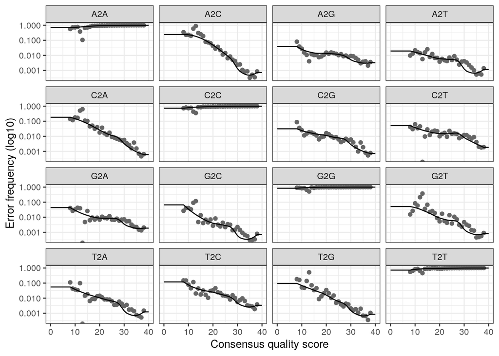

```r
plotErrors(errF)
```

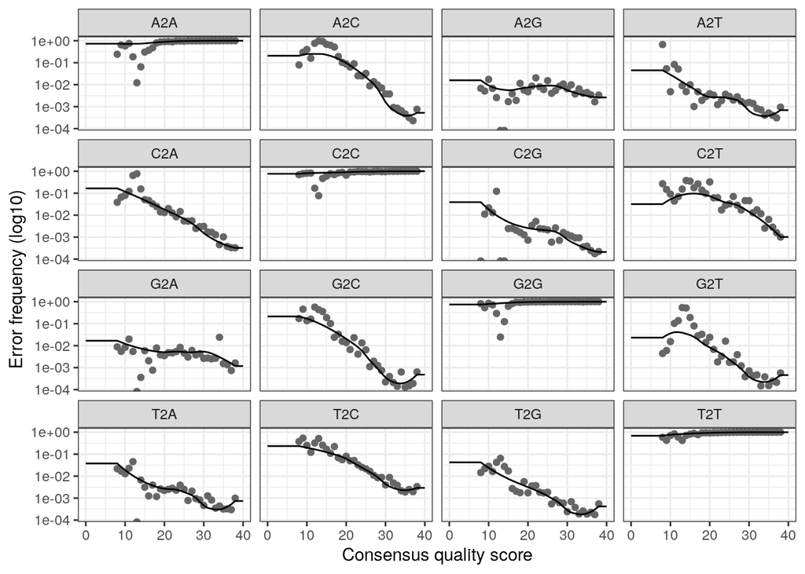

```r
plotErrors(errR)
```

On utilise la fonction dada pour calculer les erreurs dans les reads à partir des profils d’erreurs calculés précédemment. Cela aboutit à un jeu de données dans erreur de séquençage.

```r
dadaFs <- dada(derepFs, err=errF, multithread=TRUE)
```

```
## Sample 1 - 32124 reads in 15945 unique sequences.
## Sample 2 - 92838 reads in 31325 unique sequences.
## Sample 3 - 46643 reads in 16060 unique sequences.
## Sample 4 - 94277 reads in 19732 unique sequences.
## Sample 5 - 112817 reads in 26952 unique sequences.
## Sample 6 - 109440 reads in 22492 unique sequences.
## Sample 7 - 163655 reads in 24909 unique sequences.
## Sample 8 - 105908 reads in 16844 unique sequences.
## Sample 9 - 194755 reads in 29692 unique sequences.
## Sample 10 - 63926 reads in 27166 unique sequences.
## Sample 11 - 76550 reads in 14917 unique sequences.
## Sample 12 - 26037 reads in 4682 unique sequences.
## Sample 13 - 150016 reads in 33852 unique sequences.
## Sample 14 - 280864 reads in 75083 unique sequences.
## Sample 15 - 185152 reads in 56156 unique sequences.
## Sample 16 - 154076 reads in 42991 unique sequences.
## Sample 17 - 111621 reads in 36023 unique sequences.
## Sample 18 - 127863 reads in 36085 unique sequences.
## Sample 19 - 309890 reads in 67176 unique sequences.
## Sample 20 - 85811 reads in 29753 unique sequences.
## Sample 21 - 200131 reads in 46146 unique sequences.
## Sample 22 - 151300 reads in 39647 unique sequences.
## Sample 23 - 158874 reads in 53402 unique sequences.
## Sample 24 - 34173 reads in 11271 unique sequences.
```

```r
dadaRs <- dada(derepRs, err=errR, multithread=TRUE)
```

```
## Sample 1 - 32124 reads in 12951 unique sequences.
## Sample 2 - 92838 reads in 29574 unique sequences.
## Sample 3 - 46643 reads in 15456 unique sequences.
## Sample 4 - 94277 reads in 19813 unique sequences.
## Sample 5 - 112817 reads in 26574 unique sequences.
## Sample 6 - 109440 reads in 25045 unique sequences.
## Sample 7 - 163655 reads in 26287 unique sequences.
## Sample 8 - 105908 reads in 17053 unique sequences.
## Sample 9 - 194755 reads in 31404 unique sequences.
## Sample 10 - 63926 reads in 22023 unique sequences.
## Sample 11 - 76550 reads in 17749 unique sequences.
## Sample 12 - 26037 reads in 5638 unique sequences.
## Sample 13 - 150016 reads in 39391 unique sequences.
## Sample 14 - 280864 reads in 77965 unique sequences.
## Sample 15 - 185152 reads in 58694 unique sequences.
## Sample 16 - 154076 reads in 39995 unique sequences.
## Sample 17 - 111621 reads in 32416 unique sequences.
## Sample 18 - 127863 reads in 35266 unique sequences.
## Sample 19 - 309890 reads in 71048 unique sequences.
## Sample 20 - 85811 reads in 28013 unique sequences.
## Sample 21 - 200131 reads in 51746 unique sequences.
## Sample 22 - 151300 reads in 34667 unique sequences.
## Sample 23 - 158874 reads in 51298 unique sequences.
## Sample 24 - 34173 reads in 9557 unique sequences.
```

```r
dadaFs[[1]]
```

```
## dada-class: object describing DADA2 denoising results
## 380 sequence variants were inferred from 15945 input unique sequences.
## Key parameters: OMEGA_A = 1e-40, OMEGA_C = 1e-40, BAND_SIZE = 16
```

Construire une table de sq & supprimer les chimères

```r
#On aligne les forwards et les reverses en 1 seul fragment qui couvre toute la portion V4 du gène.
mergers <- mergePairs(dadaFs, derepFs, dadaRs, derepRs)

#On créer une table de séquence représentant le nombre de fois ou chaque ASV est présent dans chacun des échantillons.
seqtabAll <- makeSequenceTable(mergers[!grepl("Mock", names(mergers))])
table(nchar(getSequences(seqtabAll)))
```

```
##
##  240  243  244  252  256  262  266  268  269  270  271  272  273  274  275  276
##    2    1    1    2    2    1    2    4    7   11    1    2    4    7   23    7
##  279  280  281  282  283  284  285  286  287  288  289  290  291  292  293  294
##    1    1    7    9   23  105   89  367  575 1320 1200  882 1775  839 1835 2811
##  295  296  297  298  299  300  301  302  303  304  305  306  308  309  310  311
## 1048  467  686  192  117   63   53   10    5    2    2    7    3    4    1    1
##  312  313  318  319  330  334  335
##    1    1    2    1    1    1    1
```

```r
seqtabNoC <- removeBimeraDenovo(seqtabAll)
```

CONSTRUIRE UN ARBRE PHYLOGENETIQUE

```r
seqs <- getSequences(seqtabNoC)
names(seqs) <- seqs
alignment <- AlignSeqs(DNAStringSet(seqs), anchor=NA,verbose=FALSE)

phangAlign <- phyDat(as(alignment, "matrix"), type="DNA")
dm <- dist.ml(phangAlign)
treeNJ <- NJ(dm)
fit = pml(treeNJ, data=phangAlign)
fitGTR <- update(fit, k=4, inv=0.2)

#Cette ligne en dessous a tournée plusieurs fois pendant 3 à 5h, je trouve ca bizarre que ca charge aussi longtemps, je ne sais pas pour quelle raison. Je n'ai donc pas pu continuer la suite.. Je met un # devant sinon le knit ne fonctionne pas.
#fitGTR <- optim.pml(fitGTR, model="GTR", optInv=TRUE, optGamma=TRUE,
        #rearrangement = "stochastic", control = pml.control(trace = 0))
#detach("package:phangorn", unload=TRUE)
```